# R Notebook

Himesh Buch

## Data

The dataset for this assignment is called `milk`, from the `rethinking` package. It describes the composition of milk for various primates. There is a description of the variables at https://www.rdocumentation.org/packages/rethinking/versions/1.59/topics/milk

Here’s a description, from the book *Statistical Rethinking* by McElreath:

A popular hypothesis has it that primates with larger brains produce more energetic milk, so that brains can grow quickly. … The question here is to what extent energy content of milk, measured here by kilocalories, is related to the percent of the brain mass that is neocortex. … We’ll end up needing female body mass as well, to see the masking that hides the relationships among the variables.

```r
data(milk, package = "rethinking") # this command is needed to make the dataset available

milk %>%
  glimpse()
```

```
Rows: 29
Columns: 8
$ clade          <fct> Strepsirrhine, Strepsirrhine, Strepsirrhine, Strepsirr…
$ species        <fct> Eulemur fulvus, E macaco, E mongoz, E rubriventer, Lem…
$ kcal.per.g     <dbl> 0.49, 0.51, 0.46, 0.48, 0.60, 0.47, 0.56, 0.89, 0.91, …
$ perc.fat       <dbl> 16.60, 19.27, 14.11, 14.91, 27.28, 21.22, 29.66, 53.41…
$ perc.protein   <dbl> 15.42, 16.91, 16.85, 13.18, 19.50, 23.58, 23.46, 15.80…
$ perc.lactose   <dbl> 67.98, 63.82, 69.04, 71.91, 53.22, 55.20, 46.88, 30.79…
$ mass           <dbl> 1.95, 2.09, 2.51, 1.62, 2.19, 5.25, 5.37, 2.51, 0.71, …
$ neocortex.perc <dbl> 55.16, NA, NA, NA, NA, 64.54, 64.54, 67.64, NA, 68.85,…
```

```r
milk %>%
  skim()
```

```
── Data Summary ────────────────────────
                           Values
Name                       Piped data
Number of rows             29
Number of columns          8
_______________________
Column type frequency:
  factor                   2
  numeric                  6
________________________
Group variables            None

── Variable type: factor ───────────────────────────────────────────────────────
  skim_variable n_missing complete_rate ordered n_unique
1 clade                 0             1 FALSE          4
2 species               0             1 FALSE         29
  top_counts
1 Ape: 9, New: 9, Old: 6, Str: 5
2 A p: 1, Alo: 1, Cal: 1, Cal: 1

── Variable type: numeric ──────────────────────────────────────────────────────
  skim_variable  n_missing complete_rate   mean     sd    p0   p25   p50   p75
1 kcal.per.g             0         1      0.642  0.161  0.46  0.49  0.6   0.73
2 perc.fat               0         1     34.0   14.3    3.93 21.2  36.8  46.1
3 perc.protein           0         1     16.4    4.85   7.37 13    15.8  20.8
4 perc.lactose           0         1     49.6   14.1   27.1  37.8  48.6  60.1
5 mass                   0         1     14.7   24.8    0.12  1.62  3.47 10.7
6 neocortex.perc        12         0.586 67.6    5.97  55.2  64.5  68.8  71.3
   p100 hist
1  0.97 ▇▁▃▂▂
2 55.5  ▂▆▆▇▇
3 25.3  ▂▇▆▅▅
4 71.9  ▇▇▇▅▇
5 97.7  ▇▁▁▁▁
6 76.3  ▃▃▆▇▆
```

Since there are a number of missing observations, we will restrict to just the complete cases.

```r
milk_complete <-
  na.omit(milk)
```

Here’s a quick plot of the data.

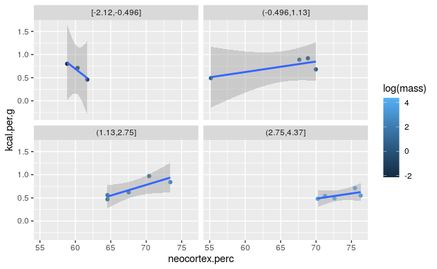

```r
milk_complete %>%
  ggplot(aes(neocortex.perc, kcal.per.g, colour = log(mass))) +
  geom_point() +
  geom_smooth(method = "lm") +
  facet_wrap(~ cut_interval(log(mass), 4))
```

It looks like there might well be a relationship among neocortex.perc, kcal.per.g, and log(mass), even if it’s not super compelling.

## Models

```r
milk_fit1 <- stan_glm(kcal.per.g ~ perc.lactose, data = milk_complete)
```

```
starting worker pid=3995 on localhost:11484 at 21:42:30.595
starting worker pid=4009 on localhost:11484 at 21:42:30.799
starting worker pid=4023 on localhost:11484 at 21:42:31.007
starting worker pid=4037 on localhost:11484 at 21:42:31.215
```

```r
milk_fit2 <- stan_glm(kcal.per.g ~ neocortex.perc, data = milk_complete)
```

```
starting worker pid=4061 on localhost:11484 at 21:42:43.048
starting worker pid=4075 on localhost:11484 at 21:42:43.255
starting worker pid=4090 on localhost:11484 at 21:42:43.456
starting worker pid=4104 on localhost:11484 at 21:42:43.657
```

```r
milk_fit3 <- stan_glm(kcal.per.g ~ log(mass), data = milk_complete)
```

```
starting worker pid=4126 on localhost:11484 at 21:42:52.440
starting worker pid=4140 on localhost:11484 at 21:42:52.642
starting worker pid=4154 on localhost:11484 at 21:42:52.844
starting worker pid=4168 on localhost:11484 at 21:42:53.046
```

```r
milk_fit4 <- stan_glm(kcal.per.g ~ neocortex.perc + log(mass), data = milk_complete)
```

```
starting worker pid=4190 on localhost:11484 at 21:43:01.850
starting worker pid=4204 on localhost:11484 at 21:43:02.048
starting worker pid=4218 on localhost:11484 at 21:43:02.247
starting worker pid=4232 on localhost:11484 at 21:43:02.444
```

```r
milk_fit5 <- stan_glm(kcal.per.g ~ neocortex.perc * log(mass), data = milk_complete)
```

```
starting worker pid=4254 on localhost:11484 at 21:43:11.447
starting worker pid=4268 on localhost:11484 at 21:43:11.643
starting worker pid=4282 on localhost:11484 at 21:43:11.842
starting worker pid=4296 on localhost:11484 at 21:43:12.040
```

Use `shinystan` to check the the results (they all look acceptable). Remember you have to either click the red square in the code chunk, or close the shinystan window, to be able to continue in RStudio.

```r
launch_shinystan(milk_fit1)
```

```r
launch_shinystan(milk_fit2)
```

```r
launch_shinystan(milk_fit3)
```

## Model comparison

```r
milk_loo1 <- loo(milk_fit1, k_threshold = 0.7)
```

```
All pareto_k estimates below user-specified threshold of 0.7.
Returning loo object.
```

```r
milk_loo2 <- loo(milk_fit2, k_threshold = 0.7)
```

```
All pareto_k estimates below user-specified threshold of 0.7.
Returning loo object.
```

```r
milk_loo3 <- loo(milk_fit3, k_threshold = 0.7)
```

```
All pareto_k estimates below user-specified threshold of 0.7.
Returning loo object.
```

```r
milk_loo4 <- loo(milk_fit4, k_threshold = 0.7)
```

If you get a warning, follow the instructions in the warning to redo it.

We only use the `loo()` function so that we can compare models, so now we can actually compare them.

```r
loo_compare(
  milk_loo1,
  milk_loo2,
  milk_loo3,
  milk_loo4,
  milk_loo5
)
```

[output not shown]

```
          elpd_diff se_diff
milk_fit1   0.0       0.0
milk_fit4 -11.9       2.9
milk_fit5 -12.2       2.8
milk_fit3 -15.7       2.1
milk_fit2 -16.5       2.3
```

## Last look at the model and the data

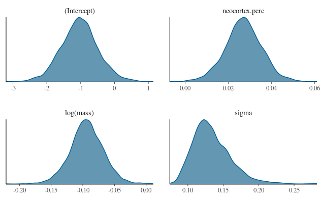

```r
plot(milk_fit4, plotfun = "dens")
```